# responce_pap_correlation

## Response Draft: Correlated PAP Responses

We appreciate the reviewer’s concern that correlations among PAP response variables could influence model interpretation.

Our view is that some correlation among PAP responses is expected because several PAP metrics summarize related properties of the same assemblage structure.

We nevertheless performed a dedicated robustness analysis and removed collinear PAP responses before re-running the H1 spatial SPD models.

To make this transparent, we report the workflow using three linked figures: (A) grouped PAP correlation diagnostics, (B) changes in untruncated signed hierarchical contributions after response reduction as a supplementary decomposition diagnostic, and (C) reduced-response reconstruction of the main zero-truncated spatial summary pattern.

### A. Correlation structure among PAP responses

Figure A documents where response-metric overlap is strongest and which PAP pairs are most likely to create redundancy in downstream models.

Across 45 PAP pairs, 3 had median absolute correlation >= 0.8 and 1 had median absolute correlation >= 0.9.

The highest-correlation pairs were n1 vs n2 (0.958); n1 vs n1_minus_n2 (0.850); n0 vs n1_minus_n2 (0.846).

This supports the reviewer’s point that some response metrics are strongly correlated and justifies running a reduced-response sensitivity model.

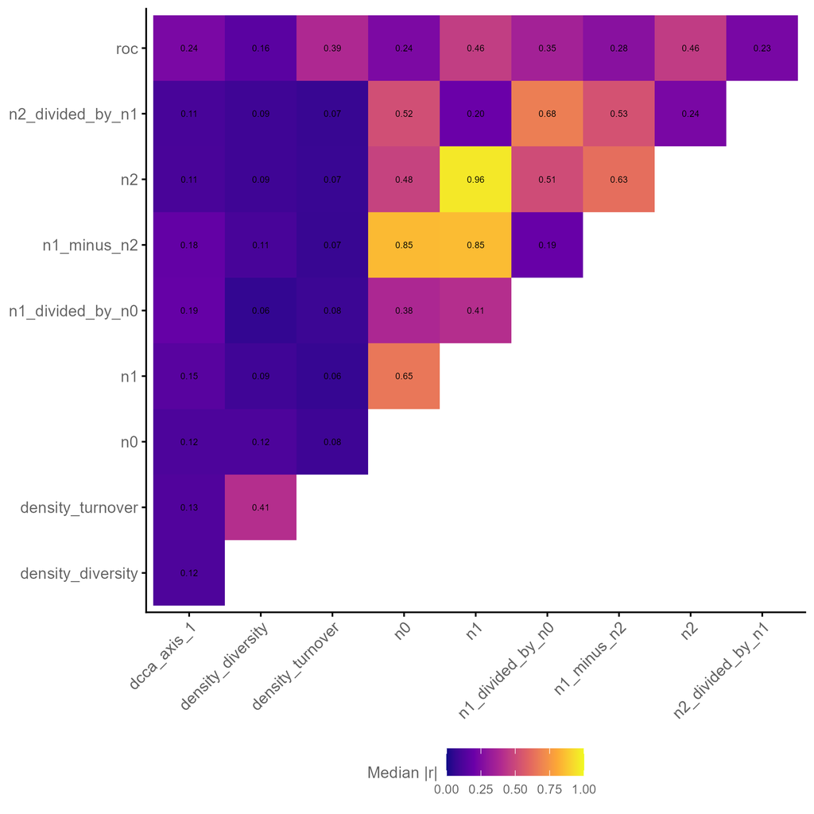

Figure 1: Pairwise PAP correlation diagnostics used to identify collinear response variables.

### B. Supplementary effect on untruncated signed hierarchical contributions

Figure B shows the direct model-comparison result after removing collinear PAP responses. Untruncated signed hierarchical contributions are retained, including negative values; missing values are not replaced with zero. A negative signed contribution is an adjusted partitioning result and does not imply a negative ecological effect.

This comparison includes 1,262 datasets, with 1,114 datasets that had complete baseline and reduced model pairs.

The median untruncated signed climate hierarchical contribution changed from 0.798 in the baseline model to 0.794 in the reduced-response model.

The median untruncated signed human hierarchical contribution changed from 0.202 to 0.207.

The median change in the signed climate contribution (reduced minus baseline) was -9.78e-03, which is effectively zero at practical precision.

Climate remained larger than human in 938 baseline datasets and 978 reduced-response datasets with non-missing paired values.

The strongest median absolute pairwise PAP correlation observed across grouped diagnostics was 0.958.

Only 75 datasets switched dominance class (climate-dominant vs human-dominant) between baseline and reduced-response runs.

Larger shifts were limited: 125 of 1,114 complete pairs had an absolute change in signed climate contribution >= 0.2 (11.2%).

These sensitivity results show that reducing correlated PAP responses does not materially change the main conclusion that climate retains a larger hierarchical contribution than human predictors at the focal spatial and temporal scales.

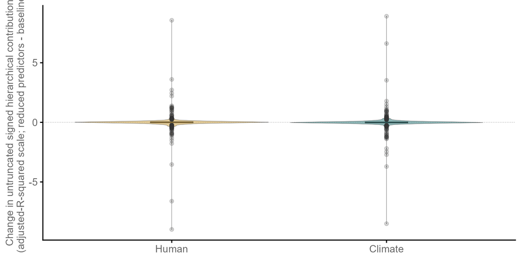

Figure 2: Sensitivity of untruncated signed hierarchical contributions after reducing collinear PAP responses. This is a supplementary decomposition diagnostic; missing values are retained as missing.

### C. Visual pattern check against the main spatial summary

Figure C compares the reduced-response output in the same visual summary style used for the main H1 spatial interpretation.

The broad spatial pattern remains unchanged, with climate-dominant structure retained across most region-climate combinations, indicating that the key interpretation is not an artifact of response redundancy.

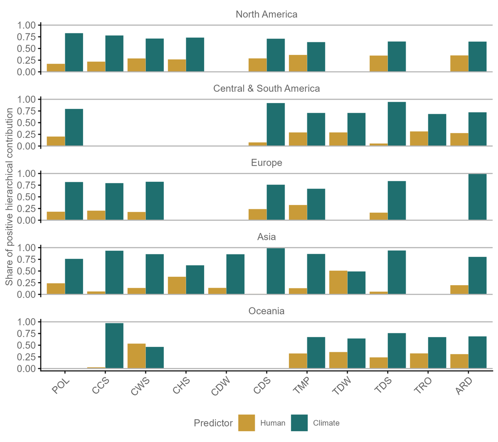

Figure 3: Reduced-response reconstruction of the simple spatial summary pattern used for visual comparison with the main result.

### Notes for manuscript integration

- Methods: Add one sentence stating that a collinearity-based reduced-PAP sensitivity analysis was run.
- Results: Report that baseline and reduced-PAP models yield near-identical median untruncated signed climate and human hierarchical contributions in the supplementary diagnostic.
- Discussion: Clarify that expected metric inter-correlation does not alter the central inference.